# Homework 2

Yanyu Chen

Assigned: 27 October 2021

## This homework is due by **next class**. To complete this assignment, follow these steps:

1. Download the `homework2.Rmd` file from Canvas.
2. Open `homework2.Rmd` in RStudio.
3. Replace the “your name here” text in the `author:` field with your own name.
4. Supply your solutions to the homework by editing `homework2.Rmd`.
5. When you have completed the homework and have **checked** that your code both runs in the Console and knits correctly when you click `Knit HTML`, save the html file as `homework2_YourAndrewIDHere.html`, and submit on Canvas. (YourAndrewIDHere should be changed to your Andrew ID, of course.)

## Homework tips:

1. Instead of sending code line-by-line with `<ctrl-enter>`, you can send entire code chunks, and even run all of the code chunks in your .Rmd file. Look under the menu of the Source panel.
2. Run your code in the Console and Knit HTML frequently to check for errors.
3. You may find it easier to solve a problem by interacting only with the Console at first.

## Homework 2 outline

## Problem 1: Simple Boolean operations

> Tip: To check that your answer makes sense, you may want to try it out in the console with various choices of values for the variable `x`.

## (a) Checking equality.

Given a variable `x`, write a Boolean expression that evaluates to `TRUE` if the variable `x` is equal to `4935` (the numeric value).

```r
x <- 20
x == 4935
```

```
## [1] FALSE
```

## (b) Checking inequality.

Given any variable `x`, write a Boolean expression that evaluates to `TRUE` if the variable `x` is *not* `NA` (i.e., is not missing).

```r
!is.na(x)
```

```
## [1] TRUE
```

## (c) Checking if a number is in a given range.

Given a (possibly negative) number `x`, write a Boolean expression that returns `TRUE` if and only if `x` is less than `-14` OR greater than `71`.

```r
(x < -14) | (x > 71)
```

```
## [1] FALSE
```

## Problem 2: Vector Boolean operations

## (a) R has two kinds of Boolean operators implemented, single (`&`, `|`) and double (`&&`, `||`).

One of these operators takes advantage of something called *lazy evaluation* while the other does not. They also don’t behave the same way when applied to *vectors*.

Read the help file (`help("||")`) and construct some examples to help figure out how the two behave.

To help you get started, try out the following two examples in your console:

```r
# Example:  The variable y.prob2a is not defined.
# (Do not define it!)
# What happens when you run this code?
x.prob2a <- 5
(x.prob2a < 10) | (y.prob2a > 2)
(x.prob2a < 10) || (y.prob2a > 2)
```

```r
# Define vectors
x.prob2a.vec <- c(TRUE, FALSE, FALSE)
y.prob2a.vec <- c(TRUE, TRUE, FALSE)

# Apply various Boolean operations to see what happens
x.prob2a.vec & y.prob2a.vec
```

```
## [1]  TRUE FALSE FALSE
```

```r
x.prob2a.vec && y.prob2a.vec
```

```
## [1] TRUE
```

```r
x.prob2a.vec | y.prob2a.vec
```

```
## [1]  TRUE  TRUE FALSE
```

```r
x.prob2a.vec || y.prob2a.vec
```

```
## [1] TRUE
```

Can you explain what’s happening? Write up a brief explanation below.

**For question 2, ‘|’ showed error because y.prob2a is not defined, but ‘||’ showed TRUE. For question 2a, & and | can return a vector, and && and || only return a single boolean value. Maybe this is because | and & will check every element of each vector in this operation and return a vector of boolean value. But && and || only check the first element of each vector (from left to right) and return a single boolean value..**

## (b) Using `all()`

Two people were asked to give their preferences between two options: [Facebook, Twitter], [Firefox, Chrome], [Mac, PC], [Summer, Winter]. Their results are given below.

```r
alice_prefs <- c("Twitter", "Chrome", "Mac", "Summer")
bob_prefs <- c("Facebook", "Chrome", "PC", "Winter")
```

Use the `all()` function to determine if the two people have identical preferences. (Your code should ouput a single Boolean value, either `TRUE` or `FALSE`)

```r
all(alice_prefs == bob_prefs)
```

```
## [1] FALSE
```

## (c) Using `any()`

Use the `any()` function to determine if the two people have any preferences in common. (Your code should output a single Boolean value, either `TRUE` or `FALSE`)

```r
any(alice_prefs == bob_prefs)
```

```
## [1] TRUE
```

## (d) Missing values.

Let `age` be the vector defined below.

```r
age <- c(18, 17, 25, 71, NA, 45, NA, 65, 18, 52)
```

Write a Boolean expression that checks whether each entry of `age` is missing (recall missing values are denoted by `NA`). Your expression should return a Boolean vector having the same length as `age`.

```r
v <- c(is.na(age))
v
```

```
##  [1] FALSE FALSE FALSE FALSE  TRUE FALSE  TRUE FALSE FALSE FALSE
```

## Problem 3: Referencing vector elements

## (a) `which()` practice

Write code that returns the indexes of `age` that are missing.

```r
which(v)
```

```
## [1] 5 7
```

## (b) Getting non-missing values

Write code that uses negative indexes and your solution from (a) to return only the values of `age` that are *not* missing. (i.e., your code should result in a vector with elements: 18, 17, 25, 71, 45, 65, 18, 52)

```r
age[-which(v)]
```

```
## [1] 18 17 25 71 45 65 18 52
```

## (c) A more direct way of getting non-missing values

Using the negation operator `!` and the `is.na()` function, write an expression that returns only the values of `age` that are *not* missing.

```r
age[!is.na(age)]
```

```
## [1] 18 17 25 71 45 65 18 52
```

## (d) More `which()` practice

For the next three problems we will go back to the `cars` data set.

```r
speed <- cars$speed
dist <- cars$dist
```

Write code to figure out which of the entries in cars has a stopping distance (dist) of 15 feet or more.

```r
cars[which(dist >= 15),]
```

```
##    speed dist
## 4      7   22
## 5      8   16
## 7     10   18
## 8     10   26
## 9     10   34
## 10    11   17
## 11    11   28
## 13    12   20
## 14    12   24
## 15    12   28
## 16    13   26
## 17    13   34
## 18    13   34
## 19    13   46
```

[output cut: 31 more lines]

## (e) `which.min`, `which.max` practice

Use the `which.min()` function to figure out which car had the *shortest* stopping distance. (Your code should return the car’s index.)

```r
which.min(dist)
```

```
## [1] 1
```

## (f) More practice

Use the `which.max()` function to figure out the *speed* of the car that had the *longest* stopping distance. (Your code should return the car’s speed.)

```r
cars[which.max(dist),'speed']
```

```
## [1] 24
```

## Problem 4: Data frame basics

## (a) Importing data.

Use the `read.csv()` function to import the survey data into a variable called `survey`.

```r
survey <- read.csv('survey.csv')
colnames(survey)[1] <- "X"
survey
```

```
##     X Program                PriorExp          Rexperience OperatingSystem
## 1   1     PPM         Some experience           Never used        Mac OS X
## 2   2     PPM Never programmed before           Never used         Windows
## 3   3     PPM         Some experience     Basic competence        Mac OS X
## 4   4   Other         Some experience     Basic competence        Mac OS X
## 5   5     PPM Never programmed before           Never used         Windows
## 6   6     PPM Never programmed before           Never used         Windows
## 7   7     PPM         Some experience     Basic competence        Mac OS X
## 8   8   Other         Some experience     Basic competence         Windows
## 9   9     PPM         Some experience     Basic competence         Windows
## 10 10   Other Never programmed before           Never used         Windows
## 11 11    MISM         Some experience     Basic competence         Windows
## 12 12     PPM         Some experience Installed on machine        Mac OS X
## 13 13    MISM    Extensive experience     Basic competence         Windows
## 14 14   Other         Some experience           Never used         Windows
```

[output cut: 49 more lines]

**Tip**: The csv data file called `survey.csv` is available on Canvas. You may download the file to a directory on your machine then import it.

## (b) `$` notation

Use the `$` operator to select and return the contents of the TVhours column from the `survey` dataset

```r
survey$TVhours
```

```
##  [1]  2 15 16  0  2  5  0  4  0  0 14  6 10 15  4  4 10  7 33  8  8  3  0  0  0
## [26]  0  6  1  0  0  4
```

## (c) [,] notation

Repeat part (b) using `[]` notation. i.e., Use `[]` notation to select the TVhours column from the `survey` data by position (i.e., obtain this column by using the proper column number)

```r
which(colnames(survey) == 'TVhours')
```

```
## [1] 6
```

```r
survey[6]
```

```
##    TVhours
## 1        2
## 2       15
## 3       16
## 4        0
## 5        2
## 6        5
## 7        0
## 8        4
## 9        0
## 10       0
## 11      14
## 12       6
## 13      10
## 14      15
```

[output cut: 17 more lines]

## (d) [[]] notation

Repeat part (c) with [[]] notation.

```r
survey[['TVhours']]
```

```
##  [1]  2 15 16  0  2  5  0  4  0  0 14  6 10 15  4  4 10  7 33  8  8  3  0  0  0
## [26]  0  6  1  0  0  4
```

## (e) `subset()` practice

Use the `subset()` function to select all the survey data on Program and OperatingSystem for respondents whose Rexperience is “Never used” *OR* who watched 6 or more hours of TV last week.

```r
subset(survey, select = c('Program', 'OperatingSystem'),
       subset = (Rexperience == "Never used" | TVhours >= 6))
```

```
##    Program OperatingSystem
## 1      PPM        Mac OS X
## 2      PPM         Windows
## 3      PPM        Mac OS X
## 5      PPM         Windows
## 6      PPM         Windows
## 10   Other         Windows
## 11    MISM         Windows
## 12     PPM        Mac OS X
## 13    MISM         Windows
## 14   Other         Windows
## 17     PPM        Mac OS X
## 18     PPM         Windows
## 19     PPM        Mac OS X
## 20   Other         Windows
## 21     PPM         Windows
## 27     PPM        Mac OS X
## 30     PPM         Windows
## 31   Other        Mac OS X
```

## Problem 5: Data summaries and inline code practice.

## (a) Bar graph

Create a bar graph of respondents’ Rexperience.

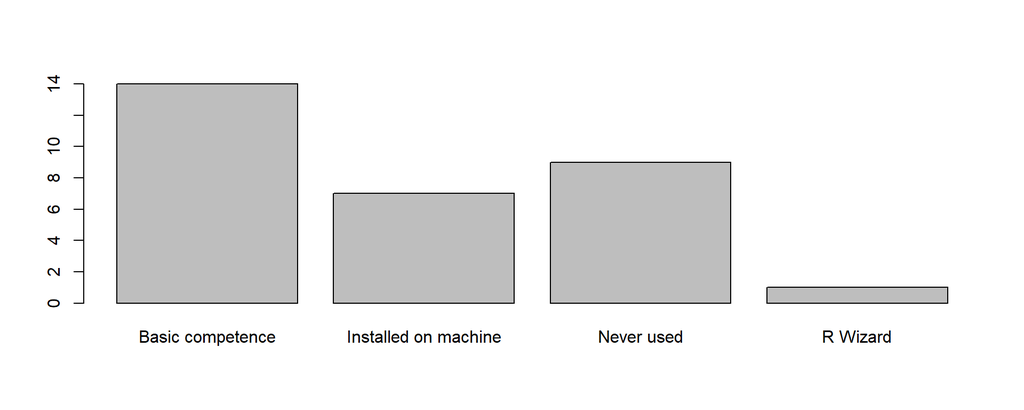

```r
survey$Rexperience <- as.factor(survey$Rexperience)
plot(survey$Rexperience)
```

## (b) Inline code practice

Replace all occurrences of ???? in the paragraph below with inline code supplying the appropriate information.

> Of the 31 survey respondents, 27 were NOT from the MISM program. We found that 35.483871% of the all students in the class use the Mac OS X operating system. 50% of of MISM students report having Basic competence in R.